# Practical Machine Learning

Javier González Onrubia

28 de marzo de 2018

## Summary

This project uses data from a Human Activity Recognition (HAR) project that tries to classify how well does an individual do a given exercise (http://groupware.les.inf.puc-rio.br/har). Our goal is find a classifier model that predicts how well (the `classe` variable) the exercise was done.

This project uses 2 different models based on classification trees and random forests, finding out the latter to be a best fit for prediction.

Additionally, a brief analysis on the random forest model is done, showing which predictors explain the most of the variability and how many of them give the better results.

And finally, a 20-case testing data is used to predict the `classe` that each observation belongs to.

## Data Cleaning

First of all, we load the training data and the testing one, the latter being used as the quiz testing set.

```r
download.file(
    "https://d396qusza40orc.cloudfront.net/predmachlearn/pml-training.csv",
    "pml-training.csv", method = "curl")
download.file(
    "https://d396qusza40orc.cloudfront.net/predmachlearn/pml-testing.csv",
    "pml-testing.csv", method = "curl")

training <- read.csv("pml-training.csv",
                     na.strings  = c("", "NA", "#DIV/0!"))
quiz  <- read.csv("pml-testing.csv")
```

We clean the columns with a very high level of NA values (>=50%) as they won’t be useful as predictors. Other descriptive columns as X, username, measurement date/time and informational ones as new_window and num_window are also removed as predictors.

```r
# At least 50% of non-NA data available
training <- training[,colSums(!is.na(training))>=(nrow(training)*0.5)]
# Pruning columns considered not useful as predictors
training <-training[, -c(1:7)]
```

Analyzing which candidate predictors could have near-zero variance, we find no predictor that could be set apart using this criteria.

```r
library(caret)
nearZeroVar(training, saveMetrics = TRUE)
```

```
##                      freqRatio percentUnique zeroVar   nzv
## roll_belt             1.101904     6.7781062   FALSE FALSE
## pitch_belt            1.036082     9.3772296   FALSE FALSE
## yaw_belt              1.058480     9.9734991   FALSE FALSE
## total_accel_belt      1.063160     0.1477933   FALSE FALSE
## gyros_belt_x          1.058651     0.7134849   FALSE FALSE
## gyros_belt_y          1.144000     0.3516461   FALSE FALSE
## gyros_belt_z          1.066214     0.8612782   FALSE FALSE
## accel_belt_x          1.055412     0.8357966   FALSE FALSE
## accel_belt_y          1.113725     0.7287738   FALSE FALSE
## accel_belt_z          1.078767     1.5237998   FALSE FALSE
## magnet_belt_x         1.090141     1.6664968   FALSE FALSE
## magnet_belt_y         1.099688     1.5187035   FALSE FALSE
## magnet_belt_z         1.006369     2.3290184   FALSE FALSE
## roll_arm             52.338462    13.5256345   FALSE FALSE
## pitch_arm            87.256410    15.7323412   FALSE FALSE
## yaw_arm              33.029126    14.6570176   FALSE FALSE
## total_accel_arm       1.024526     0.3363572   FALSE FALSE
## gyros_arm_x           1.015504     3.2769341   FALSE FALSE
## gyros_arm_y           1.454369     1.9162165   FALSE FALSE
## gyros_arm_z           1.110687     1.2638875   FALSE FALSE
## accel_arm_x           1.017341     3.9598410   FALSE FALSE
## accel_arm_y           1.140187     2.7367241   FALSE FALSE
## accel_arm_z           1.128000     4.0362858   FALSE FALSE
## magnet_arm_x          1.000000     6.8239731   FALSE FALSE
## magnet_arm_y          1.056818     4.4439914   FALSE FALSE
## magnet_arm_z          1.036364     6.4468454   FALSE FALSE
## roll_dumbbell         1.022388    84.2065029   FALSE FALSE
## pitch_dumbbell        2.277372    81.7449801   FALSE FALSE
## yaw_dumbbell          1.132231    83.4828254   FALSE FALSE
## total_accel_dumbbell  1.072634     0.2191418   FALSE FALSE
## gyros_dumbbell_x      1.003268     1.2282132   FALSE FALSE
## gyros_dumbbell_y      1.264957     1.4167771   FALSE FALSE
## gyros_dumbbell_z      1.060100     1.0498420   FALSE FALSE
## accel_dumbbell_x      1.018018     2.1659362   FALSE FALSE
## accel_dumbbell_y      1.053061     2.3748853   FALSE FALSE
## accel_dumbbell_z      1.133333     2.0894914   FALSE FALSE
## magnet_dumbbell_x     1.098266     5.7486495   FALSE FALSE
## magnet_dumbbell_y     1.197740     4.3012945   FALSE FALSE
## magnet_dumbbell_z     1.020833     3.4451126   FALSE FALSE
## roll_forearm         11.589286    11.0895933   FALSE FALSE
## pitch_forearm        65.983051    14.8557741   FALSE FALSE
## yaw_forearm          15.322835    10.1467740   FALSE FALSE
## total_accel_forearm   1.128928     0.3567424   FALSE FALSE
## gyros_forearm_x       1.059273     1.5187035   FALSE FALSE
## gyros_forearm_y       1.036554     3.7763735   FALSE FALSE
## gyros_forearm_z       1.122917     1.5645704   FALSE FALSE
## accel_forearm_x       1.126437     4.0464784   FALSE FALSE
## accel_forearm_y       1.059406     5.1116094   FALSE FALSE
## accel_forearm_z       1.006250     2.9558659   FALSE FALSE
## magnet_forearm_x      1.012346     7.7667924   FALSE FALSE
## magnet_forearm_y      1.246914     9.5403119   FALSE FALSE
## magnet_forearm_z      1.000000     8.5771073   FALSE FALSE
## classe                1.469581     0.0254816   FALSE FALSE
```

Finally, we’ll be using 52 predictors.

## Subsetting data into training and test set

As the `quiz` data can’t be used as a testing set, we split 25% os the training data to be used as the testing set. We call this set as the `holdout` set since as we’ll be using cross-validation, each training sample will be tested against the test sample of each of the folds.

```r
set.seed(12345)

# Subsetting training data into training and testing sets
inTraining <- createDataPartition(training$classe, p = 0.75, list = FALSE)
trainset <- training[inTraining,]
holdout <- training[-inTraining,]
```

This subsetting gives as for 14718 observations for the training set and 4904 observations for the holdout one.

### Parallelizing

To increase training performance the `parallel` and `doParallel` packages were used as follows:

```r
library(parallel)
library(doParallel)
cluster <- makeCluster(detectCores()-1)
registerDoParallel(cluster)
```

## Classifying

As for classifying methods, we’ll be using classification trees and random forests, both of them using 5-fold cross-validation. To build the model we’ll use the `trainset` data and the `holdout` as the testing set to validate how good they fit the data not considered in building the model.

```r
fitControl <- trainControl(method = "cv", number = 5, allowParallel = TRUE)

m.rf <- train(classe~., method = "rf", data = trainset, trControl = fitControl)
m.rpart <- train(classe~., method = "rpart", data = trainset, trControl = fitControl)
stopCluster(cluster)
registerDoSEQ()
```

Looking at the accuracy for the 5-fold cross-validation:

```r
m.rpart$results
```

```
##           cp  Accuracy      Kappa AccuracySD   KappaSD
## 1 0.02430457 0.5718878 0.45593981 0.02583551 0.0388307
## 2 0.04158359 0.4737593 0.30270463 0.10112929 0.1668110
## 3 0.11706067 0.3327208 0.07384966 0.04415335 0.0674214
```

```r
m.rf$results
```

```
##   mtry  Accuracy     Kappa  AccuracySD     KappaSD
## 1    2 0.9907600 0.9883109 0.002429003 0.003071791
## 2   27 0.9921866 0.9901157 0.001399519 0.001769417
## 3   52 0.9895370 0.9867641 0.002368813 0.002995406
```

We get a 57.19% accuracy for the classification tree and a 99.22% accuracy for the random forest method. As the latter gives us the best accuracy, we’ll select this method for further predictions.

Nevertheless, the confusion matrix for both methods using the `holdout` data as a best-fit evaluator confirms the random forest as the best model.

```r
confusionMatrix(predict(m.rpart, holdout), holdout$classe)
```

```
## Confusion Matrix and Statistics
##
##           Reference
## Prediction   A   B   C   D   E
##          A 870 162  29  46  16
##          B 159 530  36 136 221
##          C 273 214 674 429 224
##          D  88  43 116 193  51
##          E   5   0   0   0 389
##
## Overall Statistics
##
##                Accuracy : 0.5416
##                  95% CI : (0.5275, 0.5556)
##     No Information Rate : 0.2845
##     P-Value [Acc > NIR] : < 2.2e-16
##
##                   Kappa : 0.4245
##  Mcnemar's Test P-Value : < 2.2e-16
##
## Statistics by Class:
##
##                      Class: A Class: B Class: C Class: D Class: E
## Sensitivity            0.6237   0.5585   0.7883  0.24005  0.43174
## Specificity            0.9279   0.8604   0.7184  0.92732  0.99875
## Pos Pred Value         0.7747   0.4898   0.3716  0.39308  0.98731
## Neg Pred Value         0.8611   0.8904   0.9414  0.86155  0.88647
## Prevalence             0.2845   0.1935   0.1743  0.16395  0.18373
## Detection Rate         0.1774   0.1081   0.1374  0.03936  0.07932
## Detection Prevalence   0.2290   0.2206   0.3699  0.10012  0.08034
## Balanced Accuracy      0.7758   0.7095   0.7534  0.58368  0.71525
```

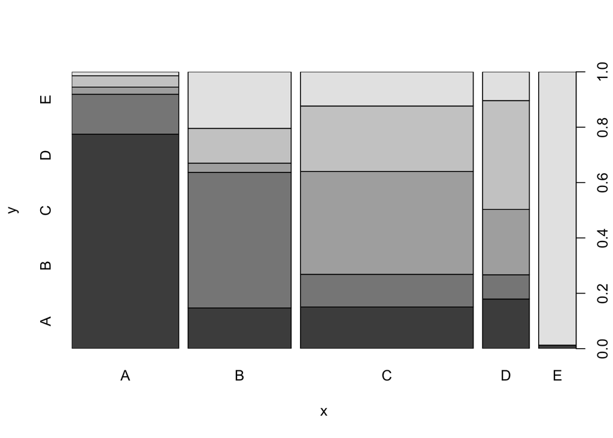

```r
plot(predict(m.rpart, holdout), holdout$classe)
```

```r
confusionMatrix(predict(m.rf, holdout), holdout$classe)
```

```
## Confusion Matrix and Statistics
##
##           Reference
## Prediction    A    B    C    D    E
##          A 1394    6    0    0    0
##          B    1  939    3    0    0
##          C    0    4  848    8    2
##          D    0    0    4  796    6
##          E    0    0    0    0  893
##
## Overall Statistics
##
##                Accuracy : 0.9931
##                  95% CI : (0.9903, 0.9952)
##     No Information Rate : 0.2845
##     P-Value [Acc > NIR] : < 2.2e-16
##
##                   Kappa : 0.9912
##  Mcnemar's Test P-Value : NA
##
## Statistics by Class:
##
##                      Class: A Class: B Class: C Class: D Class: E
## Sensitivity            0.9993   0.9895   0.9918   0.9900   0.9911
## Specificity            0.9983   0.9990   0.9965   0.9976   1.0000
## Pos Pred Value         0.9957   0.9958   0.9838   0.9876   1.0000
## Neg Pred Value         0.9997   0.9975   0.9983   0.9980   0.9980
## Prevalence             0.2845   0.1935   0.1743   0.1639   0.1837
## Detection Rate         0.2843   0.1915   0.1729   0.1623   0.1821
## Detection Prevalence   0.2855   0.1923   0.1758   0.1644   0.1821
## Balanced Accuracy      0.9988   0.9942   0.9942   0.9938   0.9956
```

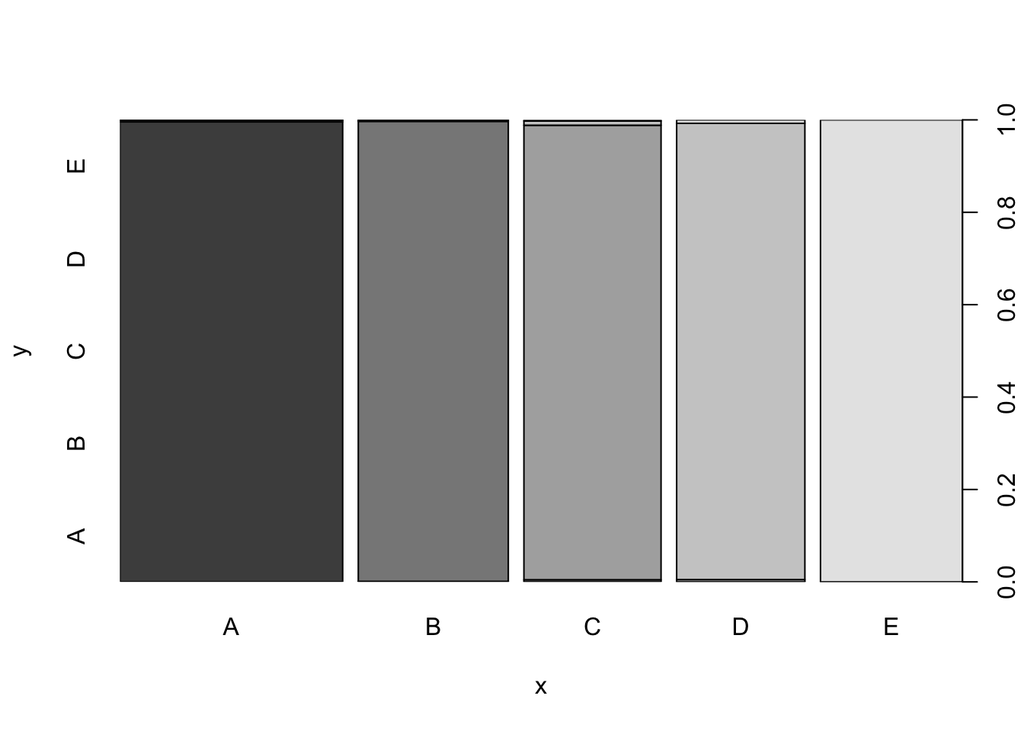

```r
plot(predict(m.rf, holdout), holdout$classe)
```

## The Random forest model

```r
m.rf
```

```
## Random Forest
##
## 14718 samples
##    52 predictor
##     5 classes: 'A', 'B', 'C', 'D', 'E'
##
## No pre-processing
## Resampling: Cross-Validated (5 fold)
## Summary of sample sizes: 11775, 11773, 11774, 11775, 11775
## Resampling results across tuning parameters:
##
##   mtry  Accuracy   Kappa
##    2    0.9907600  0.9883109
##   27    0.9921866  0.9901157
##   52    0.9895370  0.9867641
##
## Accuracy was used to select the optimal model using the largest value.
## The final value used for the model was mtry = 27.
```

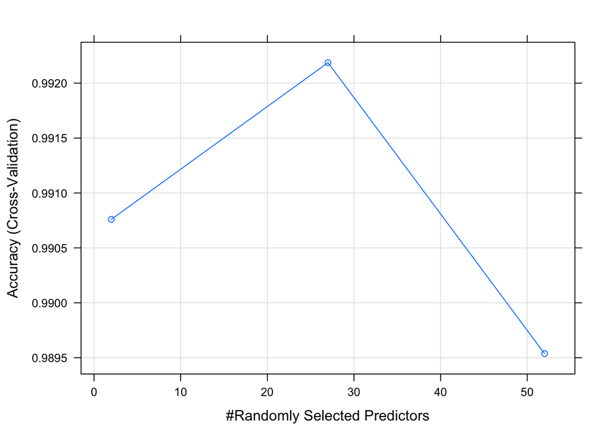

```r
plot(m.rf)
```

### OOB Error rate

```r
mean(m.rf$finalModel$err.rate[,"OOB"])
```

```
## [1] 0.007608555
```

### Predictor importance

As for the predictor importance:

```r
library(randomForest)
library(dplyr)
```

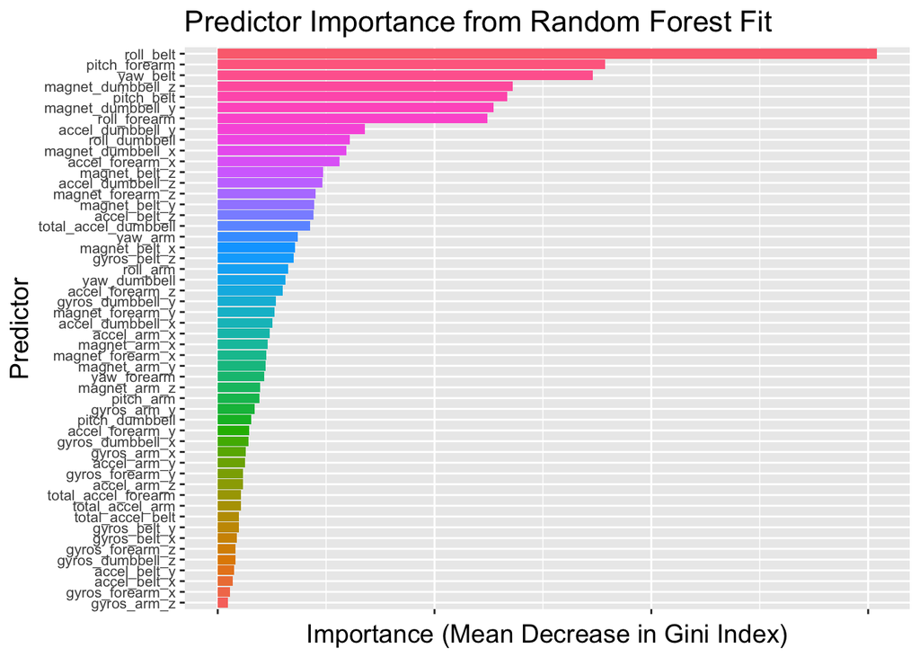

```r
pred_importance <- data.frame(
                        predictor = setdiff(colnames(trainset), "classe"),
                        importance=as.vector(importance(m.rf$finalModel))
        )
pred_importance <- arrange(pred_importance, importance)
pred_importance$predictor <- factor(pred_importance$predictor,
                                   levels=pred_importance$predictor)

p <- ggplot(pred_importance, aes(x=predictor, weight=importance, fill=predictor))
p <- p + geom_bar() + coord_flip()
p <- p + ggtitle("Predictor Importance from Random Forest Fit")
p <- p + xlab("Predictor") + ylab("Importance (Mean Decrease in Gini Index)")
p <- p + scale_fill_discrete(name="Predictor")
p + theme(axis.text.x=element_blank(),
          axis.text.y=element_text(size=8),
          axis.title=element_text(size=14),
          plot.title=element_text(size=16),
          legend.position = "none")
```

## Quiz prediction

```r
predict(m.rf, quiz)
```

```
##  [1] B A B A A E D B A A B C B A E E A B B B
## Levels: A B C D E
```